# Biomass bins and age structure

Summer flounder, scup, and black sea bass

Sarah Gaichas

2023-11-30

## Objective

Create a range of biomass and associated age structures for summer flounder based on the 2023 MT assessment. This will be used to parameterize a relationship between summer flounder population structure and expectation of catch given regs from the recreational demand model.

## Approach

Take the 2023 MT assessment input and output files as a starting point. Find max and min B relative to the reference point and most extreme age structures (all young, all old) from the assessment. Can we get a relationship (or eliminate unlikely combinations) of B/Bmsy and age structure that is realistic for this stock?

## Range of B/Bmsy from assessment

### Summer flounder

Mark Terciero provided the files from the 2023 MT assessment. They are in this repo in the `fluke2023MTfiles` folder: https://github.com/NOAA-EDAB/MAFMCrecMeasures/tree/main/fluke2023MTfiles

First, here in mac land we need to change filenames to have lowercase extensions. Done by hand.

We want the following from the .rep file:

- Population Numbers at the Start of the Year
- Biomass Time Series

This is findable in the .rdat file using Chris Legault and Liz Brook’s ASAPplots functions:

```r
# try Legault's asapPlots functions to read rep/rdat

#devtools::install_github("cmlegault/ASAPplots", build_vignettes = TRUE)

#library(ASAPplots)

asap.name <- "F2023_NEWSET_ESS_V1"
wd <- here::here("fluke2023MTfiles")

#test from plotASAP.r lines 42-43
rdat <- paste0(asap.name,".rdat")
asap <- dget(paste0(wd,"/",rdat)) # modified from windows specific backslash

# # desired objects
# asap$SSB
#
# asap$exploitable.B
#
# asap$tot.jan1.B
#
# asap$N.age
```

Add reference points from assessment:

Download from https://apps-nefsc.fisheries.noaa.gov/saw/sasi.php

Search Criteria Used

- Assessment Year: 2023
- Species Name: Summer flounder
- Stock Area: Summer flounder
- Review Type: Level 2 Expedited Review
- Information Type: All

Table 2 of `Summer_flounder_MTA_2023_06_08_130636.678006.pdf` has reference points

$SSB_{msy}$ in 2023 is 49561

Show SSB from assessment relative to $SSB_{msy}$:

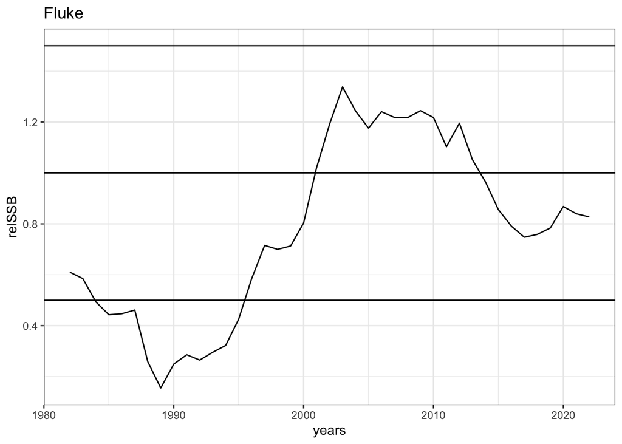

```r
SSBmsy <- 49561

relSSB <- asap$SSB/SSBmsy

years <- asap$parms$styr:asap$parms$endyr

SSBdat <- data.frame(years = years,
                     relSSB = relSSB,
                     SSB = asap$SSB,
                     explB = asap$exploitable.B,
                     totB = asap$tot.jan1.B)

ggplot2::ggplot(SSBdat, ggplot2::aes(x = years, y = relSSB)) +
  ggplot2::geom_line() +
  ggplot2::geom_hline(yintercept = 1.5) +
  ggplot2::geom_hline(yintercept = 1) +
  ggplot2::geom_hline(yintercept = 0.5) +
  ggplot2::theme_bw() +
  ggplot2::ggtitle("Fluke")
```

Lines represent three “bins” with B > Bmsy in the top bin, 0.5 Bmsy <B < B msy in the center and B < 0.5 Bmsy at the bottom.

B has never been above 1.5 Bmsy in this time series. Will have to punt on that one or use max B.

Summarize in each bin:

```r
SSBbins <- SSBdat |>
  dplyr::mutate(bin = dplyr::case_when(relSSB > 1.5 ~ "high above target",
                                dplyr::between(relSSB, 1.0,1.5) ~ "above target",
                                dplyr::between(relSSB, 0.5,1.0) ~ "below target",
                                relSSB < 0.5 ~ "overfished"))

binsummary <- SSBbins |>
  dplyr::group_by(bin) |>
  dplyr::summarise(meanSSB = mean(SSB),
                   meanexplB = mean(explB),
                   meantotB = mean(totB),
                   nyears = dplyr::n())

binsummary
```

```
## # A tibble: 3 × 5
##   bin          meanSSB meanexplB meantotB nyears
##   <chr>          <dbl>     <dbl>    <dbl>  <int>
## 1 above target  58937.    57080.   72695.     13
## 2 below target  37628.    36448.   51946.     16
## 3 overfished    16928.    22313.   32374.     12
```

We could characterize age structure associated with B in each bin.

```r
Nage <- asap$N.age |>
  as.data.frame() |>
  tibble::rownames_to_column(var = "years") |>
  dplyr::mutate(years = as.integer(years)) |>
  dplyr::rename_with(~ paste0("age", .), -years)

ageSSBbins <- SSBbins |>
  dplyr::left_join(Nage) |>
  dplyr::mutate(total = rowSums(dplyr::across(starts_with("age"))),
     dplyr::across(starts_with("age"), ~ ./total * 100, .names = 'per_{.col}')) |>
  dplyr::select(years, relSSB, bin, starts_with("per_age")) |>
  tidyr::pivot_longer(starts_with("per_age"), values_to = "per_age", names_to = "age") |>
  tidyr::separate(age, into = c("A", "age"), sep = "per_age")
```

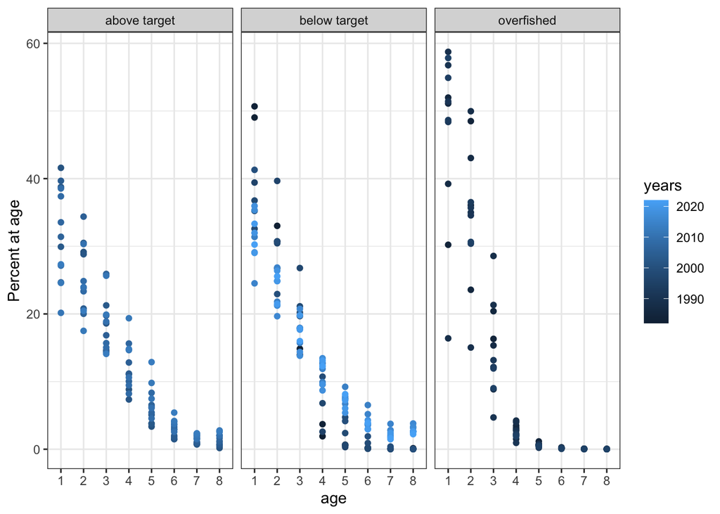

```r
ggplot2::ggplot(ageSSBbins, ggplot2::aes(x=age, y=per_age, colour = years)) +
  ggplot2::geom_point() +
  ggplot2::facet_wrap(~bin) +
  ggplot2::theme_bw() +
  ggplot2::ylab("Percent at age")
```

Can we convert these to length frequencies? Use the weight at age matrix for SSB and convert with a length-weight relationship from StockEFF (survey for all species). No StockEFF for summer flounder, use Mark’s values for summer flounder MSE:

Wkg = a*Lcm^b a= 0.00000355809 b = 3.278

```r
WAAssb <- asap$WAA.mats$WAA.ssb |>
  as.data.frame() |>
  tibble::rownames_to_column(var = "years") |>
  dplyr::mutate(years = as.integer(years)) |>
  tidyr::pivot_longer(-years, names_to = "Age", values_to = "WtAgekg")

Nagelong <- asap$N.age |>
  as.data.frame() |>
  tibble::rownames_to_column(var = "years") |>
  dplyr::mutate(years = as.integer(years)) |>
  tidyr::pivot_longer(-years, names_to = "Age", values_to = "NAge")

lenwt_a <- 0.00000355809
lenwt_b <- 3.278

LAAssb <- WAAssb |>
  dplyr::mutate(XLcm = exp((log(WtAgekg)-log(lenwt_a))/lenwt_b)) |>
  dplyr::left_join(Nagelong) |>
  dplyr::group_by(years) |>
  dplyr::mutate(TotN = sum(NAge, na.rm = TRUE),
                percN = NAge/TotN) |>
  dplyr::left_join(SSBbins)
```

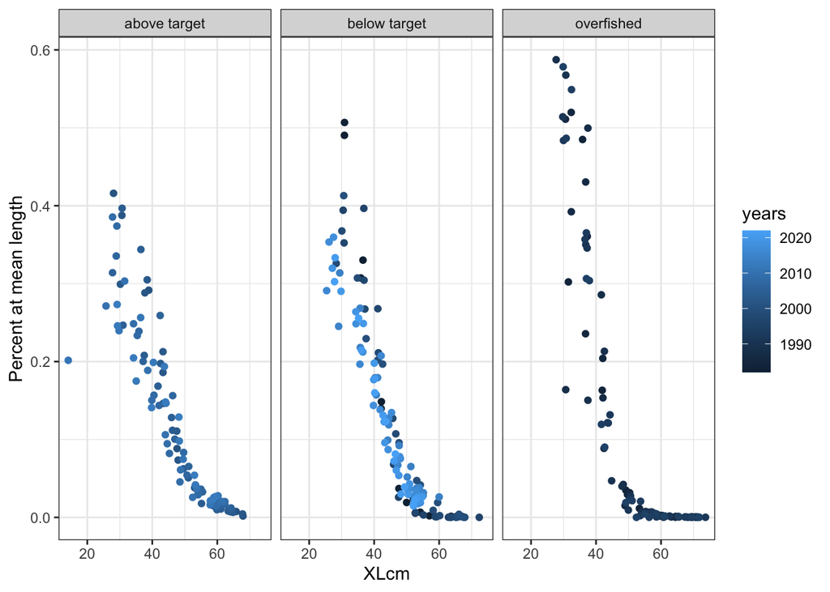

```r
ggplot2::ggplot(LAAssb, ggplot2::aes(x=XLcm, y=percN, colour = years)) +
  ggplot2::geom_point() +
  ggplot2::facet_wrap(~bin) +
  ggplot2::theme_bw() +
  ggplot2::ylab("Percent at mean length")
```

### Scup

Mark Terciero provided the files from the 2023 MT assessment. They are in this repo in the `scup2023MTfiles` folder: https://github.com/NOAA-EDAB/MAFMCrecMeasures/tree/main/scup2023MTfiles

First, here in mac land we need to change filenames to have lowercase extensions. Done by hand.

We want the following from the .rep file:

- Population Numbers at the Start of the Year
- Biomass Time Series

This is findable in the .rdat file using Chris Legault and Liz Brook’s ASAPplots functions:

```r
# try Legault's asapPlots functions to read rep/rdat

#devtools::install_github("cmlegault/ASAPplots", build_vignettes = TRUE)

#library(ASAPplots)

asap.name <- "MTA2023_NEWSET_ESS_V1"
wd <- here::here("scup2023MTfiles")

#test from plotASAP.r lines 42-43
rdat <- paste0(asap.name,".rdat")
asap <- dget(paste0(wd,"/",rdat)) # modified from windows specific backslash

# desired objects
# asap$SSB
#
# asap$exploitable.B
#
# asap$tot.jan1.B
#
# asap$N.age
```

Add reference points from assessment:

Download from https://apps-nefsc.fisheries.noaa.gov/saw/sasi.php

Search Criteria Used

- Assessment Year: 2023
- Species Name: Scup
- Stock Area: UNIT
- Review Type: Level 2 Expedited Review
- Information Type: All

Table 2 of `Scup_2023_MTA_2023_06_05_104930.21231.pdf` has reference points

$SSB_{msy}$ in 2023 is 78593

Show SSB from assessment relative to $SSB_{msy}$:

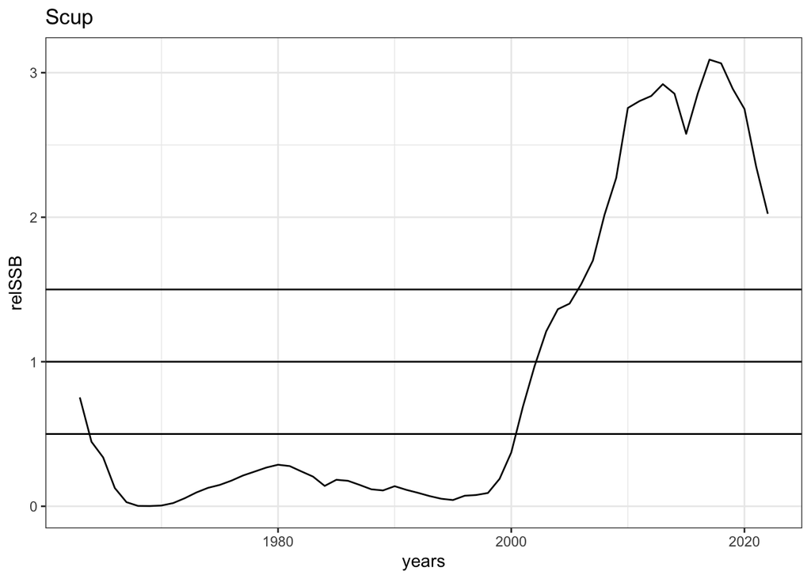

```r
SSBmsy <- 78593

relSSB <- asap$SSB/SSBmsy

years <- asap$parms$styr:asap$parms$endyr

SSBdat <- data.frame(years = years,
                     relSSB = relSSB,
                     SSB = asap$SSB,
                     explB = asap$exploitable.B,
                     totB = asap$tot.jan1.B)

ggplot2::ggplot(SSBdat, ggplot2::aes(x = years, y = relSSB)) +
  ggplot2::geom_line() +
  ggplot2::geom_hline(yintercept = 1.5) +
  ggplot2::geom_hline(yintercept = 1) +
  ggplot2::geom_hline(yintercept = 0.5) +
  ggplot2::theme_bw() +
  ggplot2::ggtitle("Scup")
```

Lines represent three “bins” with B > Bmsy in the top bin, 0.5 Bmsy <B < B msy in the center and B < 0.5 Bmsy at the bottom.

B has been above 1.5 Bmsy in this time series so we can summarize age comps in all 4 bins.

Summarize in each bin:

```r
SSBbins <- SSBdat |>
  dplyr::mutate(bin = dplyr::case_when(relSSB > 1.5 ~ "high above target",
                                dplyr::between(relSSB, 1.0,1.5) ~ "above target",
                                dplyr::between(relSSB, 0.5,1.0) ~ "below target",
                                relSSB < 0.5 ~ "overfished"))

binsummary <- SSBbins |>
  dplyr::group_by(bin) |>
  dplyr::summarise(meanSSB = mean(SSB),
                   meanexplB = mean(explB),
                   meantotB = mean(totB),
                   nyears = dplyr::n())

binsummary
```

```
## # A tibble: 4 × 5
##   bin               meanSSB meanexplB meantotB nyears
##   <chr>               <dbl>     <dbl>    <dbl>  <int>
## 1 above target      104167.   109962.  115477.      3
## 2 below target       63186.    72343.   75594.      3
## 3 high above target 200185.   159512.  231534.     17
## 4 overfished         11673.    19644.   25484.     37
```

We now characterize age structure associated with B in each bin.

```r
Nage <- asap$N.age |>
  as.data.frame() |>
  tibble::rownames_to_column(var = "years") |>
  dplyr::mutate(years = as.integer(years)) |>
  dplyr::rename_with(~ paste0("age", .), -years)

ageSSBbins <- SSBbins |>
  dplyr::left_join(Nage) |>
  dplyr::mutate(total = rowSums(dplyr::across(starts_with("age"))),
     dplyr::across(starts_with("age"), ~ ./total * 100, .names = 'per_{.col}')) |>
  dplyr::select(years, relSSB, bin, starts_with("per_age")) |>
  tidyr::pivot_longer(starts_with("per_age"), values_to = "per_age", names_to = "age") |>
  tidyr::separate(age, into = c("A", "age"), sep = "per_age")
```

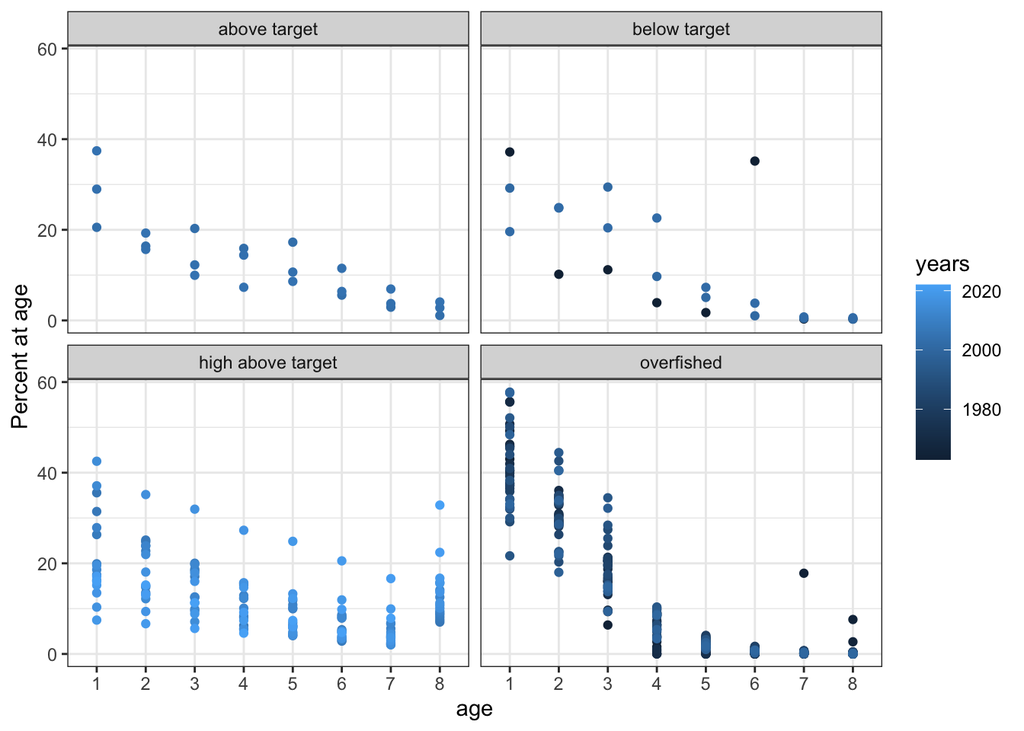

```r
ggplot2::ggplot(ageSSBbins, ggplot2::aes(x=age, y=per_age, colour = years)) +
  ggplot2::geom_point() +
  ggplot2::facet_wrap(~bin) +
  ggplot2::theme_bw() +
  ggplot2::ylab("Percent at age")
```

Can we convert these to length frequencies? Use the weight at age matrix for SSB and convert with a length-weight relationship from StockEFF (survey for all species) No length-weight in StockEFF for Scup. Using Wigley et al 2003 TM NE-171 https://repository.library.noaa.gov/view/noaa/3346/noaa_3346_DS1.pdf? for now, can sub in survey later

ln a -11.0698 b 3.1365

```r
WAAssb <- asap$WAA.mats$WAA.ssb |>
  as.data.frame() |>
  tibble::rownames_to_column(var = "years") |>
  dplyr::mutate(years = as.integer(years)) |>
  tidyr::pivot_longer(-years, names_to = "Age", values_to = "WtAgekg")

Nagelong <- asap$N.age |>
  as.data.frame() |>
  tibble::rownames_to_column(var = "years") |>
  dplyr::mutate(years = as.integer(years)) |>
  tidyr::pivot_longer(-years, names_to = "Age", values_to = "NAge")

lenwt_a <- exp(-11.0698)
lenwt_b <- 3.1365

LAAssb <- WAAssb |>
  dplyr::mutate(XLcm = exp((log(WtAgekg)-log(lenwt_a))/lenwt_b)) |>
  dplyr::left_join(Nagelong) |>
  dplyr::group_by(years) |>
  dplyr::mutate(TotN = sum(NAge, na.rm = TRUE),
                percN = NAge/TotN) |>
  dplyr::left_join(SSBbins)
```

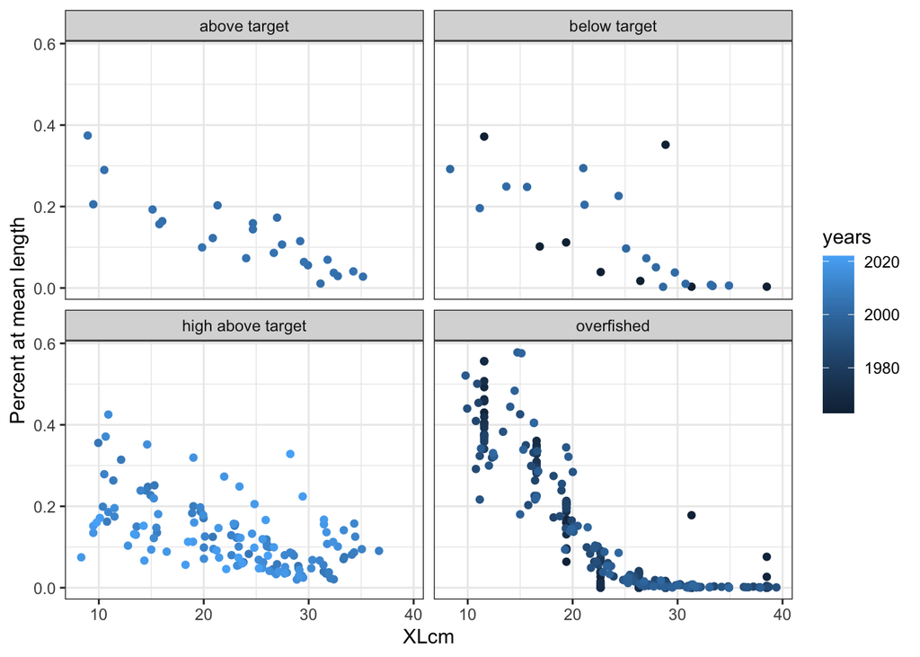

```r
ggplot2::ggplot(LAAssb, ggplot2::aes(x=XLcm, y=percN, colour = years)) +
  ggplot2::geom_point() +
  ggplot2::facet_wrap(~bin) +
  ggplot2::theme_bw() +
  ggplot2::ylab("Percent at mean length")
```

### Black Sea Bass

Kiersten Curti provided a link to the preliminary (pre-review but public) 2023 RT results: https://github.com/kcurti/BSB.2023.RT.Modeling/tree/main/2023.RT.Runs/Run34

Key outputs stored in https://github.com/NOAA-EDAB/MAFMCrecMeasures/tree/main/BSB2023RTfiles

We want the following from the output files:

- Population Numbers at the Start of the Year
- Biomass Time Series

Black Sea Bass is assessed in two areas, North and South, but reference points and status apply to the entire population. I’ll do my best to bin things to full population but also give North and South results if that is useful for the rec demand model.

Explore the WHAM rdata file:

```r
# rdata file from repo

ghrdat <- "https://github.com/kcurti/BSB.2023.RT.Modeling/raw/main/2023.RT.Runs/Run34/outputs/Run34.WHAM.Outputs.RDATA"

download.file(ghrdat, here::here("BSB2023RTfiles/Run34.WHAM.Outputs.Rdata"))
load("BSB2023RTfiles/Run34.WHAM.Outputs.Rdata")

#objects of interest

# SSB.yr.north
#
# NAA.north
#
# SSB.yr.south
#
# NAA.south
```

Reference points from WHAM output `brps`

This plot is for the whole population (north plus south)

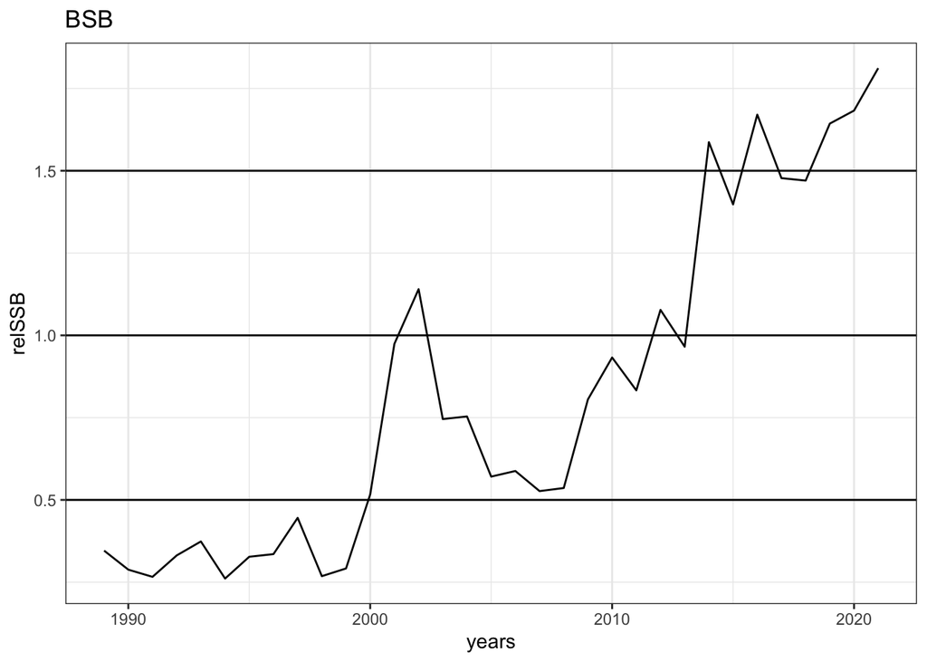

```r
SSBmsynorth <- brps$est[2]
SSBmsysouth <- brps$est[3]

SSBmsy <- brps$est[4]

relSSBnorth <- SSB.yr.north$est/SSBmsynorth
relSSBsouth <- SSB.yr.south$est/SSBmsysouth

relSSBtot <- (SSB.yr.north$est + SSB.yr.south$est)/SSBmsy

years <- model.yrs

SSBdat <- data.frame(years = years,
                     relSSB = relSSBtot,
                     SSB = SSB.yr.north$est + SSB.yr.south$est,
                     SSBnorth = SSB.yr.north$est,
                     SSBsouth = SSB.yr.south$est,
                     relSSBnorth = relSSBnorth,
                     relSSBsouth = relSSBsouth)

ggplot2::ggplot(SSBdat, ggplot2::aes(x = years, y = relSSB)) +
  ggplot2::geom_line() +
  ggplot2::geom_hline(yintercept = 1.5) +
  ggplot2::geom_hline(yintercept = 1) +
  ggplot2::geom_hline(yintercept = 0.5) +
  ggplot2::theme_bw() +
  ggplot2::ggtitle("BSB")
```

And here it is for each area. Both areas and the full population have been in all 4 bins.

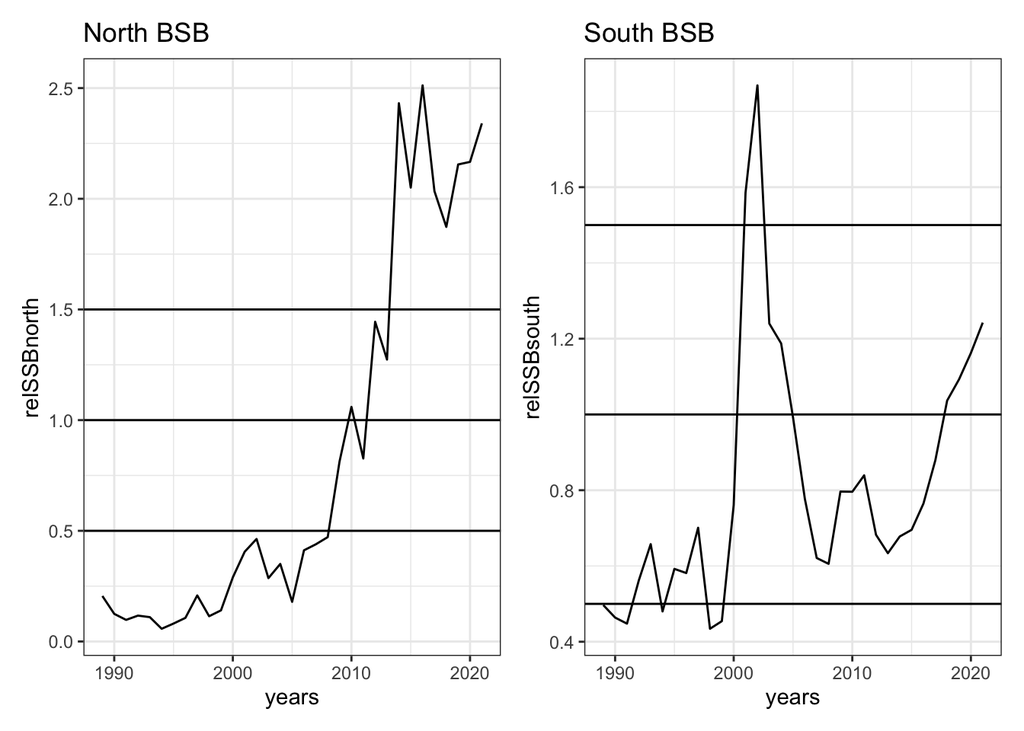

```r
north <- ggplot2::ggplot(SSBdat, ggplot2::aes(x = years, y = relSSBnorth)) +
  ggplot2::geom_line() +
  ggplot2::geom_hline(yintercept = 1.5) +
  ggplot2::geom_hline(yintercept = 1) +
  ggplot2::geom_hline(yintercept = 0.5) +
  ggplot2::theme_bw() +
  ggplot2::ggtitle("North BSB")

south <- ggplot2::ggplot(SSBdat, ggplot2::aes(x = years, y = relSSBsouth)) +
  ggplot2::geom_line() +
  ggplot2::geom_hline(yintercept = 1.5) +
  ggplot2::geom_hline(yintercept = 1) +
  ggplot2::geom_hline(yintercept = 0.5) +
  ggplot2::theme_bw() +
  ggplot2::ggtitle("South BSB")

library(patchwork)

north + south
```

Summarize in each bin (full population):

```r
SSBbins <- SSBdat |>
  dplyr::mutate(bin = dplyr::case_when(relSSB > 1.5 ~ "high above target",
                                dplyr::between(relSSB, 1.0,1.5) ~ "above target",
                                dplyr::between(relSSB, 0.5,1.0) ~ "below target",
                                relSSB < 0.5 ~ "overfished"))

binsummary <- SSBbins |>
  dplyr::group_by(bin) |>
  dplyr::summarise(meanSSB = mean(SSB),
                   nyears = dplyr::n()
                   )

binsummary
```

```
## # A tibble: 4 × 3
##   bin               meanSSB nyears
##   <chr>               <dbl>  <int>
## 1 above target       16395.      5
## 2 below target        9106.     12
## 3 high above target  20972.      5
## 4 overfished          4013.     11
```

```r
binsummaryNorth <- SSBdat |>
  dplyr::mutate(bin = dplyr::case_when(relSSBnorth > 1.5 ~ "high above target",
                                dplyr::between(relSSBnorth, 1.0,1.5) ~ "above target",
                                dplyr::between(relSSBnorth, 0.5,1.0) ~ "below target",
                                relSSBnorth < 0.5 ~ "overfished")) |>
   dplyr::group_by(bin) |>
   dplyr::summarise(meanSSBnorth = mean(SSBnorth),
                   nyears = dplyr::n()
                   )


binsummarySouth <- SSBdat |>
  dplyr::mutate(bin = dplyr::case_when(relSSBsouth > 1.5 ~ "high above target",
                                dplyr::between(relSSBsouth, 1.0,1.5) ~ "above target",
                                dplyr::between(relSSBsouth, 0.5,1.0) ~ "below target",
                                relSSBsouth < 0.5 ~ "overfished")) |>
   dplyr::group_by(bin) |>
   dplyr::summarise(meanSSBsouth = mean(SSBsouth),
                   nyears = dplyr::n()
                   )
```

Summary for north:

```r
binsummaryNorth
```

```
## # A tibble: 4 × 3
##   bin               meanSSBnorth nyears
##   <chr>                    <dbl>  <int>
## 1 above target             8152.      3
## 2 below target             5310.      2
## 3 high above target       14214.      8
## 4 overfished               1508.     20
```

Summary for south:

```r
binsummarySouth
```

```
## # A tibble: 4 × 3
##   bin               meanSSBsouth nyears
##   <chr>                    <dbl>  <int>
## 1 above target             6981.      6
## 2 below target             4312.     19
## 3 high above target       10394.      2
## 4 overfished               2785.      6
```

Age structure, full population:

```r
NAAtot <- NAA.north + NAA.south

Nage <- NAAtot |>
  as.data.frame() |>
  tibble::rownames_to_column(var = "years") |>
  dplyr::mutate(years = as.integer(years)) |>
  dplyr::rename_with(~ paste0("age", .), -years)

ageSSBbins <- SSBbins |>
  dplyr::left_join(Nage) |>
  dplyr::mutate(total = rowSums(dplyr::across(starts_with("age"))),
     dplyr::across(starts_with("age"), ~ ./total * 100, .names = 'per_{.col}')) |>
  dplyr::select(years, relSSB, bin, starts_with("per_age")) |>
  tidyr::pivot_longer(starts_with("per_age"), values_to = "per_age", names_to = "age") |>
  tidyr::separate(age, into = c("A", "age"), sep = "per_age")
```

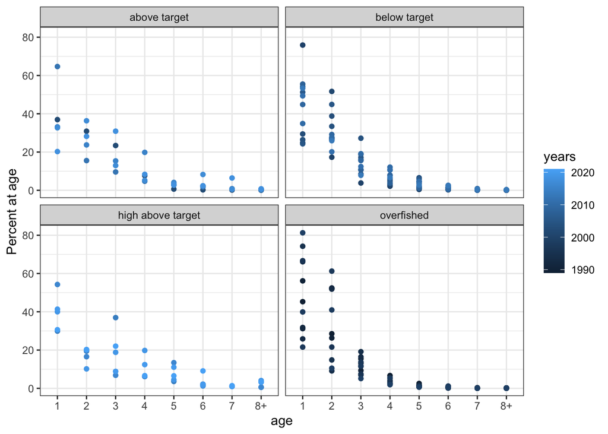

```r
ggplot2::ggplot(ageSSBbins, ggplot2::aes(x=age, y=per_age, colour = years)) +
  ggplot2::geom_point() +
  ggplot2::facet_wrap(~bin) +
  ggplot2::theme_bw() +
  ggplot2::ylab("Percent at age")
```

Age structure, North:

```r
SSBbinsN <- SSBdat |>
  dplyr::mutate(bin = dplyr::case_when(relSSBnorth > 1.5 ~ "high above target",
                                dplyr::between(relSSBnorth, 1.0,1.5) ~ "above target",
                                dplyr::between(relSSBnorth, 0.5,1.0) ~ "below target",
                                relSSBnorth < 0.5 ~ "overfished"))

Nage <- NAA.north |>
  as.data.frame() |>
  tibble::rownames_to_column(var = "years") |>
  dplyr::mutate(years = as.integer(years)) |>
  dplyr::rename_with(~ paste0("age", .), -years)

ageSSBbins <- SSBbinsN |>
  dplyr::left_join(Nage) |>
  dplyr::mutate(total = rowSums(dplyr::across(starts_with("age"))),
     dplyr::across(starts_with("age"), ~ ./total * 100, .names = 'per_{.col}')) |>
  dplyr::select(years, relSSBnorth, bin, starts_with("per_age")) |>
  tidyr::pivot_longer(starts_with("per_age"), values_to = "per_age", names_to = "age") |>
  tidyr::separate(age, into = c("A", "age"), sep = "per_age")
```

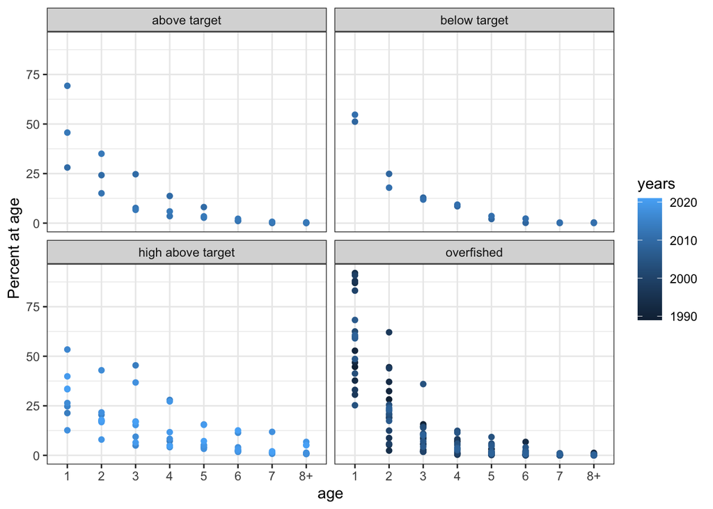

```r
ggplot2::ggplot(ageSSBbins, ggplot2::aes(x=age, y=per_age, colour = years)) +
  ggplot2::geom_point() +
  ggplot2::facet_wrap(~bin) +
  ggplot2::theme_bw() +
  ggplot2::ylab("Percent at age")
```

Age structure, South:

```r
SSBbinsS <- SSBdat |>
  dplyr::mutate(bin = dplyr::case_when(relSSBsouth > 1.5 ~ "high above target",
                                dplyr::between(relSSBsouth, 1.0,1.5) ~ "above target",
                                dplyr::between(relSSBsouth, 0.5,1.0) ~ "below target",
                                relSSBsouth < 0.5 ~ "overfished"))

Nage <- NAA.south |>
  as.data.frame() |>
  tibble::rownames_to_column(var = "years") |>
  dplyr::mutate(years = as.integer(years)) |>
  dplyr::rename_with(~ paste0("age", .), -years)

ageSSBbins <- SSBbinsS |>
  dplyr::left_join(Nage) |>
  dplyr::mutate(total = rowSums(dplyr::across(starts_with("age"))),
     dplyr::across(starts_with("age"), ~ ./total * 100, .names = 'per_{.col}')) |>
  dplyr::select(years, relSSBsouth, bin, starts_with("per_age")) |>
  tidyr::pivot_longer(starts_with("per_age"), values_to = "per_age", names_to = "age") |>
  tidyr::separate(age, into = c("A", "age"), sep = "per_age")
```

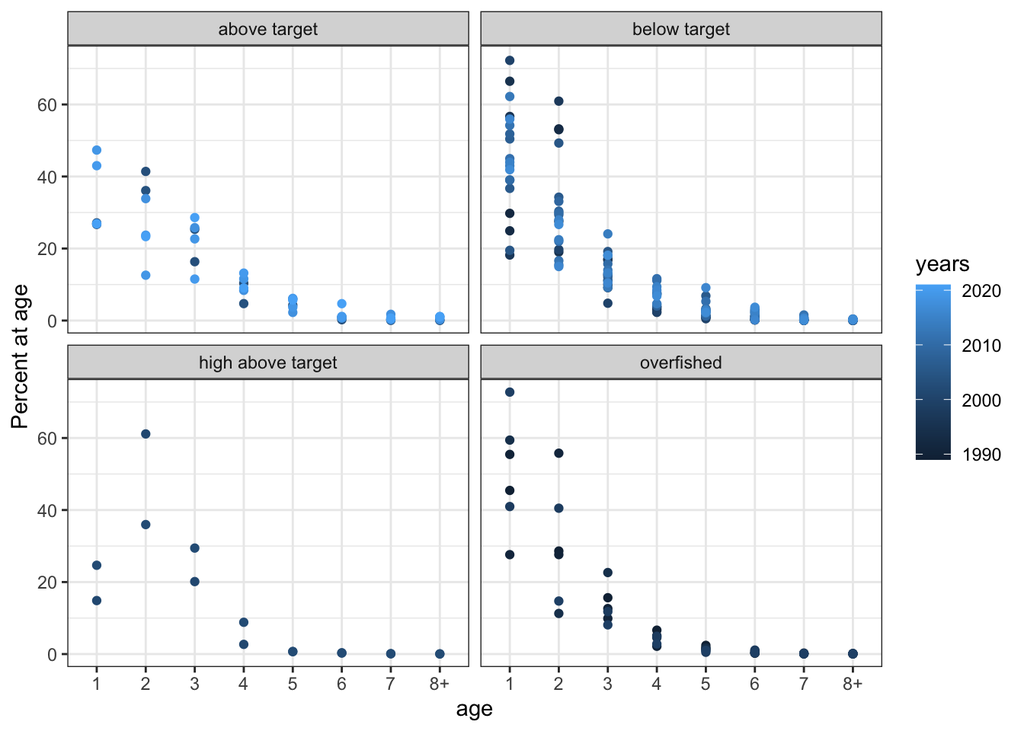

```r
ggplot2::ggplot(ageSSBbins, ggplot2::aes(x=age, y=per_age, colour = years)) +
  ggplot2::geom_point() +
  ggplot2::facet_wrap(~bin) +
  ggplot2::theme_bw() +
  ggplot2::ylab("Percent at age")
```

Can we convert these to length frequencies? Use the weight at age matrix for SSB and convert with a length-weight relationship from StockEFF (survey for all species)

WHAM doesn’t have SSBwaa so I need to dig it out. I do however have length-weight parameters for North and South

The below assumes that the first WAA matrix in input is SSBnorth and the second is SSBsouth. Check with Kiersten!

Length weight parameters from stockeff files are

North a = .000011062, b = 3.05,

South a = .0000114, b = 3.046

```r
indat <- "https://github.com/kcurti/BSB.2023.RT.Modeling/raw/main/2023.RT.Runs/Run34/res_tables/fit_input.RDS"

download.file(indat, here::here("BSB2023RTfiles/fit_input.rds"))
bsbinput <- readRDS("BSB2023RTfiles/fit_input.rds")

SSBwaaN <- bsbinput$data$waa[1,,]
colnames(SSBwaaN) <- ages.labels

SSBwaaN <- SSBwaaN |>
  as.data.frame() |>
  dplyr::mutate(years = model.yrs) |>
  tidyr::pivot_longer(-years, names_to = "Age", values_to = "WtAgekg")

NagelongN <- NAA.north |>
  as.data.frame() |>
  tibble::rownames_to_column(var = "years") |>
  dplyr::mutate(years = as.integer(years)) |>
  tidyr::pivot_longer(-years, names_to = "Age", values_to = "NAge")

#from north stockeff
lenwt_a <- .000011062
lenwt_b <- 3.05

LAAssb <- SSBwaaN |>
  dplyr::mutate(XLcm = exp((log(WtAgekg)-log(lenwt_a))/lenwt_b)) |>
  dplyr::left_join(NagelongN) |>
  dplyr::group_by(years) |>
  dplyr::mutate(TotN = sum(NAge, na.rm = TRUE),
                percN = NAge/TotN) |>
  dplyr::left_join(SSBbinsN)
```

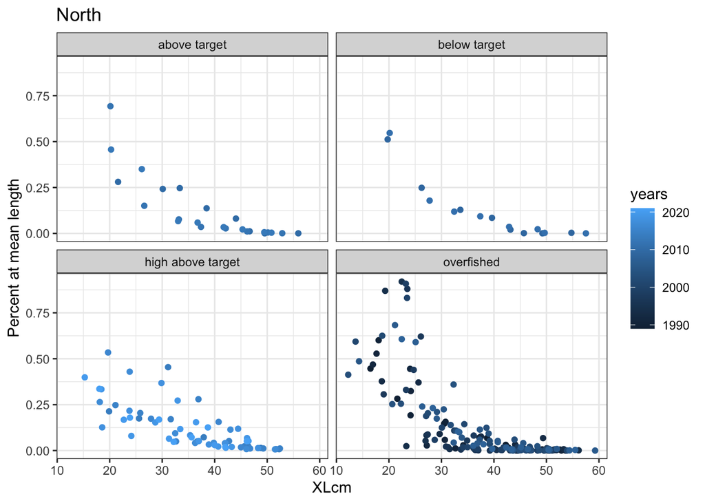

```r
ggplot2::ggplot(LAAssb, ggplot2::aes(x=XLcm, y=percN, colour = years)) +
  ggplot2::geom_point() +
  ggplot2::facet_wrap(~bin) +
  ggplot2::theme_bw() +
  ggplot2::ylab("Percent at mean length") +
  ggplot2::ggtitle("North")
```

```r
SSBwaaS <- bsbinput$data$waa[2,,]
colnames(SSBwaaS) <- ages.labels

SSBwaaS <- SSBwaaS |>
  as.data.frame() |>
  dplyr::mutate(years = model.yrs) |>
  tidyr::pivot_longer(-years, names_to = "Age", values_to = "WtAgekg")

NagelongS <- NAA.south |>
  as.data.frame() |>
  tibble::rownames_to_column(var = "years") |>
  dplyr::mutate(years = as.integer(years)) |>
  tidyr::pivot_longer(-years, names_to = "Age", values_to = "NAge")

#from north stockeff
lenwt_a <- .000011062
lenwt_b <- 3.05

LAAssb <- SSBwaaS |>
  dplyr::mutate(XLcm = exp((log(WtAgekg)-log(lenwt_a))/lenwt_b)) |>
  dplyr::left_join(NagelongS) |>
  dplyr::group_by(years) |>
  dplyr::mutate(TotN = sum(NAge, na.rm = TRUE),
                percN = NAge/TotN) |>
  dplyr::left_join(SSBbinsS)
```

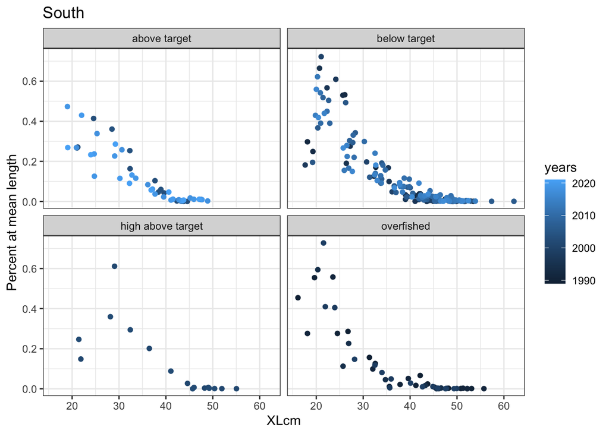

```r
ggplot2::ggplot(LAAssb, ggplot2::aes(x=XLcm, y=percN, colour = years)) +
  ggplot2::geom_point() +
  ggplot2::facet_wrap(~bin) +
  ggplot2::theme_bw() +
  ggplot2::ylab("Percent at mean length") +
  ggplot2::ggtitle("South")
```